# Quizz Session 1

## Dataset PANAS and CFQ

**1. By inspecting the scatterplot between PANAS-NA and CFQ we conclude that**

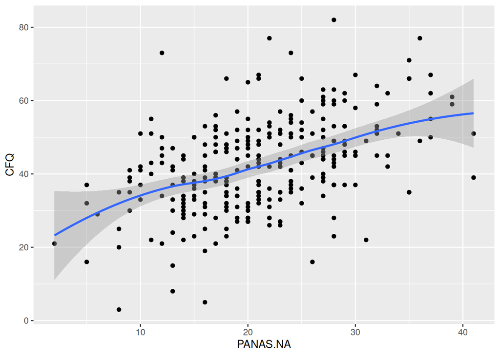

the relationship cannot be described by any known statistic despite the slight non-linear pattern we can consider a linear relationship the remarkable non-linear pattern in the relationship needs to be quantified

**2. Given the found pattern in the relationship between CFQ and PANAS-NA is adequate using a Pearson's correlation test.**

**3. The Pearson's correlation test allows us to make a decision with respect: $H_1:\rho_{XY}\neq0$**

**4. The Pearson's correlation statistic obtained in this case is indicating:**

```
    Pearson's product-moment correlation

data:  CFQ and PANAS.NA
t = 9.0148, df = 298, p-value < 2.2e-16
alternative hypothesis: true correlation is not equal to 0
95 percent confidence interval:
 0.3689993 0.5474421
sample estimates:
      cor
0.4628976
```

a positive linear relationship as r=.46 a positive linear relationship as r=9.01 independence between the variables as r is very close to 0 non-dependence between the variables as r=.46

**5. Given the p-value, we can conclude that there's a significant positive linear relationship between CFQ and PANAS-NA**

## Dataset QualitySN and RiskSE

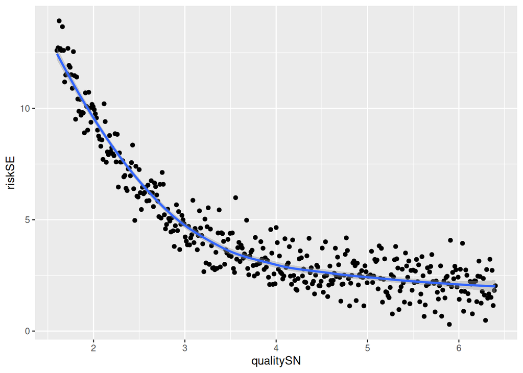

**2. Given the data at hand and the previous plot the most adequate indicator to summarize the relationship between QualitySN and RiskSE is**

Pearson's correlation Kendall's correlation Chi-squared coefficient Spearman's correlation

**3. Correlation index obtained in the sample would indicate**

```
    Spearman's rank correlation rho

data:  qualitySN and riskSE
S = 20030998, p-value < 2.2e-16
alternative hypothesis: true rho is not equal to 0
sample estimates:
       rho
-0.8639035
```

a strong negative linear relationship a weak decreasing monotonic relationship a strong decreasing monotonic relationship a weak negative linear relationship

**1. By inspecting the barplot with the joint distribution for education and phase in which the health problem is detected, we can conjecture a negative relationship between them**

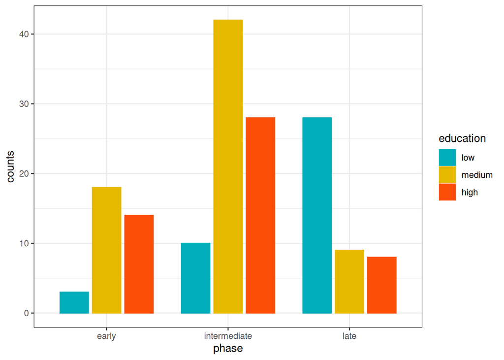

**2. Given the data at hand and the previous plot the most adequate indicator to summarize the relationship between Education and Phase is**

Pearson's correlation Kendall's correlation Covariance Spearman's correlation

**3. Correlation index between Education and Phase obtained in the sample would indicate**

```
    Kendall's rank correlation tau

data:  as.numeric(phase) and as.numeric(education)
z = -4.7003, p-value = 2.597e-06
alternative hypothesis: true tau is not equal to 0
sample estimates:
      tau
-0.334598
```

a strong decreasing relationship a moderate increasing relationship a strong increasing relationship a moderate decreasing relationship

**4. Given the test we can conclude that there's a significant relationship between education and detection phase.**

**5. Using a bootstrap with 5,000 resamples, 95% confidence level we obtain the interval equal to [-0.47;-0.19] (NOTE: Use set.seed(191124) before boot function and round limits to 2 decimals).**